# FPM4

## Review feedback and plan your revisions

**Summarize the key feedback points you received on your FPM #3 draft visualizations.**

- Need to give a better background: What is a plume? What is global warming potential? Add a picture of a plume.
- Fix color palettes - consistency
- When looking at countries, do emissions per millions of people.

**Explain which of these suggestions you plan to implement and how**- All of them!!!

- I plan to add…
  - a sentence explaining what a plume is.
  - Add a plume image or plume resemblance with plot design - make one of my bar plots into a smoke stack with a plume coming out of it.
- I tried to match the colors to the theme of the data source with color picker. Please say something if you don’t like. I was having a hard time with the country plot because its so many countries (top 10 CO2 and CH4 emitters with some overlap between the gasses = 15 countries).
- Graphing emissions per million by mutating and then graphing `emission_per_million = (total_emissions/pop) * 1e6).`

**Identify any areas where you decided not to follow feedback and explain why (e.g. “it didn’t align with my main message” or “I found a different design solution”).**

- I scratched lots of my other plots, including my previous temporal plot and map, after bouncing ideas with classmates. I found a different design solution - a stream plot that looks at emissions per country overtime.

**Address which (if any) of the ten design elements you do not plan to implement (rememeber, not all ten will necessarily apply to your project, and that’s okay!).**

- I did not apply a DEI lens to my design other than (mostly) color-blind friendly palettes.
- I do not plan to center my primary message,
- I plan to considering accessibility with colorblind-friendly palettes /contrast and alt text. But I need to go back and add alt text at the end.

# Understanding Global Carbon Dioxide & Methane Plume Emissions

[figure not shown]

Greenhouse gas emissions are warming our planet and altering natural processes at alarming rates (Figure 1). Since the industrial revolution, greenhouse gas emissions have dramatically increased. Specifically, carbon dioxide (CO2) increased from 280 parts per million (ppm) to over 410 ppm while methane (CH4) has risen from 700 parts per billion (ppb) to around 1,900 ppb. These greenhouse gasses that now overwhelm our atmosphere absorb and re-emit infrared radiation (heat) in all directions.

All to say, increase in greenhouse gasses (like carbon dioxide and methane), increase our global temperature - this is called **climate change**. Today, sea levels are rising, extreme weather events are becoming more common, and oceans are acidifying due to the rise in greenhouse gasses. Ecosystems, human health, and vital infrastructure are disrupted and even destroyed.

[figure not shown]

Figure 1

**Emission plumes** are columns of pollutants, mostly greenhouse gasses, that are released into the atmosphere. As a kid, I would always call them “cloud machines” due to the visible cloud-like gas leaking from tall smoke stack. Little did I know, the “cloud machines” were adding to air pollution and climate change.

To reduce greenhouse gas emissions, *Carbon Mapper* tracks and records global methane and carbon dioxide emission plume data. This data is made accessible to the public to promote transparency, education, and climate action.

The goal of this infographic is to further *Carbon Mapper’s* mission: use their public plume data to educate and promote local climate action, globally. Therefore, the infographic addresses these questions:

- What are plumes made of and what are the gasses characteristics?
- Who is disproportionately contributing to emission plumes?

You can check out the [full data here](https://github.com/meganhessel/EDS240infographic.git)!

### The Infographic

```r
infographic <- readJPEG(here::here("final_figs", "FPM4.4.jpg"))
plot(as.raster(infographic))
```

[figure not shown]

## **Plume Source Bar Plots**

Carbon dioxide is emitted through human activities, mostly through burning of fossil fuels for electricity and other industrial processes. CO2 is stored in trees and soils, known as being “sequestered” within these carbon dioxide sinks. Therefore, deforestation, urbanization, and land-use change removes CO2 from these natural sinks and increases atmospheric CO2 concentration.

Methane is commonly “leaked” from natural gas systems, such as livestock and solid waste. Livestock’s digestive processes produce and then off-gas CH4. As companies raise these animals in large quantities, CH4 emissions increase. Similarly to the digestive processes, as solid and water waste decomposes in large landfills, CH4 is off-gassed and released into the atmosphere. Industry is the most common methane source. Methane is used to produce, store, and transport oil and natural gas. Furthermore, coal mine methane (CMM) is realized from mines through ventilation systems, degasification/drainage systems, and post-mining activities (such as processes, storage, and transportation). CCM can be captured from the ventilation and drainage systems and used for energy production.

Understanding the emission sources can lead to creating effective emission reduction programs. By identifying key sources for each greenhouse gas, governments and organizations can tailor policies and strategies for specific emission challenges. Some solutions for emission reduction in each sector include:

| Plume Source | Solutions |
| --- | --- |
| Electricity generation’s carbon dioxide emissions | Governments and organizations can set up carbon trading systems, a carbon tax, or increase funding on renewable energy sources. |
| Solid waste’s methane emissions | Land-fill gas can be captured and used as a renewable energy source. |
| Livestock’s methane emissions | Biogas recovery systems capture and utilize natural-by-produces from digestion for clean-burning energy fuel. |
| Oil and Gas’s methane emissions | Existing programs to manage these specific emissions are performance standards that limit methane emissions from operations and increase fuel efficiency in transportation. |

When just using `ggplot`:

```r
# Data Wrangling
plumeDF_sector_tot_emission <- plumes %>%
  group_by(ipcc_sector, gas) %>%
  summarise(total_emissions = sum(emission_auto, na.rm = TRUE), # Total Emissions
            .groups = "drop") %>%
  st_drop_geometry() %>%
  filter(!ipcc_sector == "") # remove data points with no sector listed


# Turn sectors into factors
#plumeDF_sector_tot_emission$ipcc_sector <- factor(plumeDF_sector_tot_emission$ipcc_sector,
                                                     #levels = sector_order)


# Create color palette

sector_color_pal <- c("Coal Mining (1B1a)" = "#321F64",
                      "Waste Water (6B)" = "#BBBBBB",
                      "Oil & Gas (1B2)" = "#6C67DF",
                      "Livestock (4B)" = "#FFB13E",
                      "Solid Waste (6A)" = "#ED5713",
                      "Electricity Generation (1A1)" = "#20E6AC",
                      "Other" = "#7B0301")


#sector_order <- c("Coal Mining (1B1a)", "Waste Water (6B)", "Oil & Gas (1B2)", "Livestock (4B)","Solid Waste (6A)","Electricity Generation (1A1)", "Other"
#)

# Methane Sector plot
plumeDF_CH4_sector_plot <- plumeDF_sector_tot_emission %>%
  filter(gas == "CH4") %>%
  ggplot() +
  geom_bar(aes(x = "", y = total_emissions, fill = ipcc_sector), # Pie chart
           stat="identity",
           col = "black") +
  scale_fill_manual(values = sector_color_pal) +
  theme_void() +
  labs(title = "Methane Plumes",
       fill = "Sector") +
  theme(plot.title = element_text(size = 13))



# CO2 Sector plot
plumeDF_CO2_sector_plot <- plumeDF_sector_tot_emission %>%
  filter(gas == "CO2") %>%
  ggplot() +
  geom_bar(aes(x = "", y = total_emissions, fill = ipcc_sector), # Pie chart
           stat="identity",
           col = "black") +
  scale_fill_manual(values = sector_color_pal) +
  theme_void() +
  labs(title = "Carbon Dioxide Plumes",
       fill = "Sector") +
  theme(plot.title = element_text(size = 13),
        legend.position = "none")

# Plots together
plume_sector_plot <- (plumeDF_CO2_sector_plot | plumeDF_CH4_sector_plot)
plume_sector_plot
```

[figure not shown]

After polishing in Affinity:

```r
img <- png::readPNG(here::here("outputs", "sector_plot_ss.png"))
plot(as.raster(img))
```

[figure not shown]

## **Greenhouse Gas Background Plots**

Carbon dioxide has a much higher atmospheric concentration than methane as it is emitted through the burning of fossil fuels, deforestation, and industrial processes. Methane, on the other hand, is emitted through a larger variety of sources including solid waste, natural gas and petroleum systems, and livestocks. Since pre-industrial times, both greenhouse gas emissions have increased with human activities, just at different rates and concentrations. While CO2 concentration is extremely larger than CH4, methane has as 25-30 times higher global warming potential (gwp) which means 1 CH4 molecule absorbs the same infrared radiation (heat) as 25-30 CO2 molecules over 100 years. In a 20 year time period, methane traps 81-83 more heat than carbon dioxide.

This is important because both greenhouse gases have vastly different concentrations and global warming potentials which makes them both very important to climate change. Understanding both gasses characteristics and trends will help create effective climate action solutions.

When using `ggplot`:

```r
# gas colors
gas_pal <- c("CH4" = "#7F28D5",
             "CO2" = "#FFBF44")

# Total emission plot
gas_total_emissions <- plumes %>%
  group_by(gas) %>%
  summarise(emission_auto = sum(emission_auto, na.rm = TRUE)) %>%
  st_drop_geometry() %>%
  ggplot() +
  geom_col(aes(x = gas, y = emission_auto, fill = gas), col = "black") +
  scale_fill_manual(values = gas_pal) +
  theme_minimal() +
  labs(y = "Total Emission (kg/hr)") +
  theme(axis.title.x = element_blank(),
        legend.position = "none")



# GWP Comparison Circle chart
gwp <- data.frame(gas = c("CO2", "CH4"),
                  life_time = c(500, 12.4), # Chem life times
                  gwp = c(1,28)) # global warmining potential
gas_gwp_plot <- ggplot() +
  geom_point(data = gwp,
             mapping = aes(x = gas, y = 0, size = gwp, fill = gas),
             shape = 21, color = "black", alpha = 0.7) +
  scale_size_area(max_size = 20) +  # Ensures area ~ value
  coord_fixed(ratio = 5) +          # Keep circles round
  theme_minimal() +
  scale_fill_manual(values = gas_pal, guide = "none") +
  labs(
    title = "Global Warming Potiential (gwp)",
    size = "Value"
  ) +
  theme(axis.text.y = element_blank(),
        axis.ticks.y = element_blank(),
        axis.title.y = element_blank(),
        axis.title.x = element_blank(),
        legend.position = "none")

gas_total_emissions / gas_gwp_plot
```

[figure not shown]

After polishing in Affinity:

[figure not shown]

## **Emissions Per Country Steam Plot**

To understand the distribution of plume emissions on spatial and temporal scales, I created a stream plot. This plot type illustrated how carbon dioxide and methane emission rates rise and fall overtime in the top emitter countries. CO2 and CH4 are emitted at completely different rates. Having CO2 emission rates extend upwards and CH4 emission rates extend downwards allows for two different y-axis in order to compare the peaks and troughs of the greenhouse gas emission rates.

Carbon dioxide plume emissions seem to be denominated by Qatar in the early 2020s who then had a steep plume emission die off in 2024. Since then, Kuwait has taken the lead for CO2 emissions per million of people. Kuwait also emits a large amount of methane. Most importantly, Turkmenistan has consistently been the lead methane emitter.

The plots in `ggplot`:

```r
# Data wrangling
plumes_per_country <-plumes_country %>%
  st_drop_geometry() %>%
  group_by(name_long, year = year(datetime), month = month(datetime), gas) %>%  # Find avg and sum for each month of each year
  summarise(total_emissions = sum(emission_auto, na.rm = TRUE),
            avg_emissions = mean(emission_auto, na.rm = TRUE),
            pop = mean(pop),
            .groups = "drop") %>%
  mutate(year_dec = year + (month - 1) / 12, #decimal year
         emission_total_capita = (total_emissions/pop),
         emission_per_million = (total_emissions/pop) * 1e6) # per 1 million people


# Top 10 green house gas emitters
top_countries_CH4 <- plumes_per_country %>%
  filter(gas == "CH4") %>%
  group_by(name_long) %>%
  summarise(total = sum(emission_per_million)) %>%
  slice_max(total, n = 10) %>%
  pull(name_long)


top_countries_CO2 <- plumes_per_country %>%
  filter(gas == "CO2") %>%
  group_by(name_long) %>%
  summarise(total = sum(emission_per_million)) %>%
  slice_max(total, n = 10) %>%
  pull(name_long)



# Plot for CH4
plumes_per_country %>%
  filter(gas == "CH4",
         year >= 2023,
         name_long %in% top_countries_CH4) %>%
  #mutate(emission_per_million = -emission_per_million) %>%
  ggplot(aes(x = year_dec, #  use decimal year
             y = emission_per_million,
             fill = name_long)) +
  geom_stream(type = "ridge",  bw = 0.85) +
  geom_stream_label(aes(label = name_long),
                    type = "ridge",
                    size = 2.5) +
  labs(fill = "Countries") +
  theme_minimal() +
  theme(axis.title.y = element_blank(),
        axis.title.x = element_blank())
```

[figure not shown]

```r
# Plot for CO2
plumes_per_country %>%
  filter(gas == "CO2",
         year >= 2023,
         name_long %in% top_countries_CO2) %>%
  ggplot(aes(x = year_dec, #  use decimal year
             y = emission_per_million,
             fill = name_long)) +
  geom_stream(type = "ridge",  bw = 0.85) +
  geom_stream_label(aes(label = name_long),
                    type = "ridge",
                    size = 2.5) +
  labs(fill = "Countries") +
  theme_minimal() +
  theme(axis.title.y = element_blank(),
        axis.title.x = element_blank())
```

[figure not shown]

After polishing in Affinity:

[figure not shown]

## **Colors**

Most of the color palettes are color-picked from [Carbon Mapper’s website](https://carbonmapper.org/) who supplied all data used for the infographic.

The carbon dioxide and methane colors are an orange-yellow and a purple which are Carbon Mapper’s main color theme and color-blind friendly.

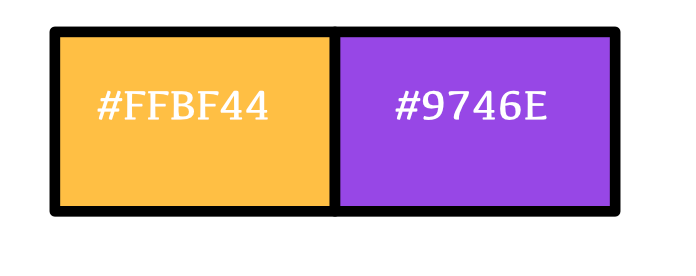

The sector color palette ranges from a dark blue to a dark red which are used to distinguish plume concentrations in Carbon Mapper’s data portal and color-blind friendly.

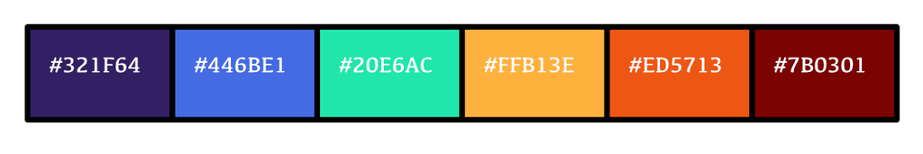

The emissions per country stream graph color palette is color-picked from the emission plume image and infographic below. These images follow the purple and yellow theme from Carbon Mapper. While these colors are not color-blind friendly, I made sure to label each country and added an annotation to help explain the plots main points.

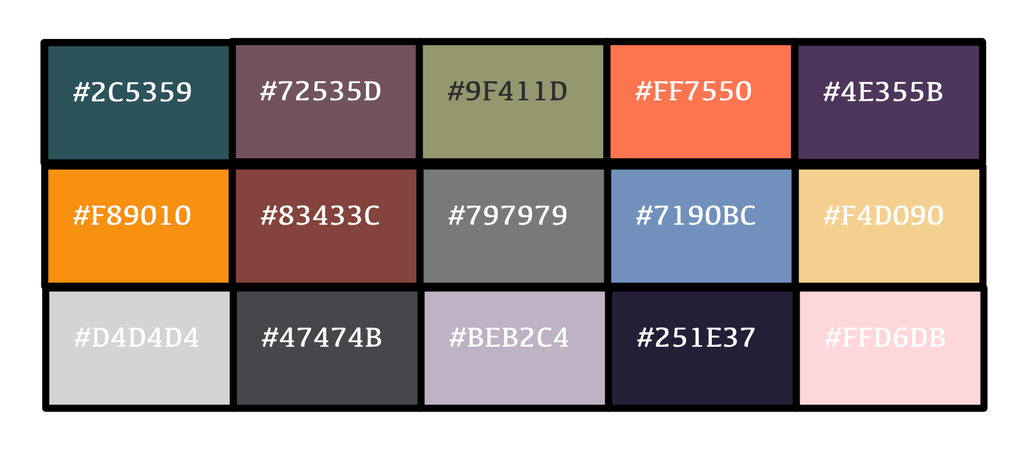

[figure not shown]

Plumes are a heavy and dark topic. Therefore, the dark background colors were to portray the same gloomy feeling.

## References

https://www.xylem.com/en-us/markets/agriculture/biogas-recovery/

https://www.epa.gov/cmop/about-coal-mine-methane

https://www.epa.gov/climateleadership/ghg-reduction-programs-strategies#Supply_Chain

https://www.epa.gov/controlling-air-pollution-oil-and-natural-gas-operations/epas-final-rule-reduce-methane-and-other